# Twitter Cleaning

Pier Lorenzo Paracchini

3 mai 2016

```r
rm(list = ls())
load(file = "./tmp/twitter_step1_all.Rdata")

set.seed(19711004)
coin.biased.outcome <- rbinom(length(data.twitter.all), 1, 0.05)
#table(coin.biased.outcome)
data.twitter.sample <- data.twitter.all[coin.biased.outcome == 1]

save(data.twitter.sample, file = "./tmp/twitter_step2_sample.1.Rdata")

set.seed(19760126)
coin.biased.outcome <- rbinom(length(data.twitter.all), 1, 0.05)
#table(coin.biased.outcome)
data.twitter.sample <- data.twitter.all[coin.biased.outcome == 1]

save(data.twitter.sample, file = "./tmp/twitter_step2_sample.2.Rdata")
rm(list = ls())
```

# Exploring the (Sample) Corpora

Exploration of the corpora is done using **natural language processing techniques** - specifically term frequency analysis using ngrams (1-gram, 2-gram and 3-gram). Before tokenizing the corpora the following steps are performed:

- transform to lower case
- remove profanity words
- remove numbers
- remove punctuations - except of the `'` (apostrophe) in order to not lose contractions (e.g. I’ll, I’m, etc)
- add a `<s>` marker at the beginning of each entry (tweet, news, blog)
- add a `</s>` marker at the end of each entry (tweet, news, blog)

`Wordclouds` and `barplots` are used to visualize the most frequent words/ tokens for the different n-grams. When plotting the ‘barplots’ only the first most frequent terms (top 30) are shown and max 200 terms in the wordclouds. **Note:** For 2-grams and 3-grams a token like `<s> at the` refers to `at the` at the beginning of the entry (tweet, news or blog), while `the top </s>` refers to `the top` at the end of the entry (tweet, news or blog).

## Twitter Corpora

```r
rm(list = ls())
load("./tmp/twitter.sample1.tdm.1g.Rdata")
load("./tmp/twitter.sample1.tdm.2g.Rdata")
load("./tmp/twitter.sample1.tdm.3g.Rdata")

load("./tmp/twitter.sample1.allTermsFrequency.1g.Rdata")
twitter.allTerms.1g <- corpora.allTermsFrequency

load("./tmp/twitter.sample1.allTermsFrequency.2g.Rdata")
twitter.allTerms.2g <- corpora.allTermsFrequency

load("./tmp/twitter.sample1.allTermsFrequency.3g.Rdata")
twitter.allTerms.3g <- corpora.allTermsFrequency
```

### 1-grams

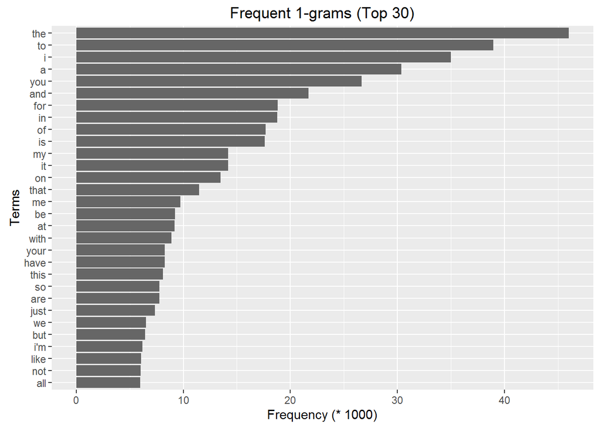

```r
getTermFrequencyInformationOrderedByTermFrequency <- function(aTdm, lowFrequency){
    ft.lf <- findFreqTerms(aTdm,lowfreq = lowFrequency)
    aTdm.l <- aTdm[ft.lf,]
    aTdm.l.asMatrix <- as.matrix(aTdm.l)
    # calculate frequency of each term
    aTdm.l.termFreq <- rowSums(aTdm.l.asMatrix)
    # create data frame from subset of terms
    aTdm.l.termFreq.df <- data.frame(term = names(aTdm.l.termFreq), freq = aTdm.l.termFreq)
    # sort by subset DataFrame frequency
    aTdm.l.termFreq.df[with(aTdm.l.termFreq.df, order(-aTdm.l.termFreq.df$freq)), ]
}

visualizeBarPlot <- function(ftm.df, colorBars = "grey40", titleBarPlot = ""){

    ggplot(ftm.df[1:30,], aes(x = reorder(term,freq), y = freq/1000)) +
        geom_bar(stat = "identity", fill=colorBars) +
        xlab("Terms") + ylab("Frequency (* 1000)")+
        ggtitle(paste(titleBarPlot, "(Top 30)"))  + coord_flip()

}

visualizeWordcloud <- function(ftm.df){
    mypal <- brewer.pal(8,"Dark2")
    wordcloud(words = ftm.df$term,
          freq = ftm.df$freq,
          colors = mypal,
          scale=c(6,.5),
          random.order = F, max.words = 200)
}

visualizeCumuluativeCoverage <- function(allFtm.df, title, filter = NULL){
    idx <- order(allFtm.df$freq, decreasing = T)
    terms.term <- rownames(allFtm.df)[idx]
    terms.freq <- allFtm.df$freq[idx]

    if(!is.null(filter)){
        # print(paste("Removing idx", filter))
        terms.term <- terms.term[-filter]
        terms.freq <- terms.freq[-filter]
    }

    terms.count <- sum(terms.freq)
    terms.unique <- length(unique(terms.term))
    terms.cumulativeCoverage <- (cumsum(terms.freq)/ terms.count) * 100


    plot(terms.cumulativeCoverage, type = "l", xlab = "Number Of Words", ylab = "% Coverage", main = title)
    abline(v = which(terms.cumulativeCoverage >= 50)[1], col = "orange", lwd = 3)
    abline(v = which(terms.cumulativeCoverage >= 90)[1], col = "red", lwd = 3)
    legend(x = "topright", lty=c(1,1), lwd=c(3,3), col=c("orange", "red"), legend = c("50% coverage", "90% coverage"))
}

getSomeInfoABoutCorpora <- function(allFtm.df, title, filter = NULL){
    idx <- order(allFtm.df$freq, decreasing = T)
    terms.term <- rownames(allFtm.df)[idx]
    terms.freq <- allFtm.df$freq[idx]

    if(!is.null(filter)){
        # print(paste("Removing idx", filter))
        terms.term <- terms.term[-filter]
        terms.freq <- terms.freq[-filter]
    }

    terms.count <- sum(terms.freq)
    terms.unique <- length(unique(terms.term))
    terms.cumulativeCoverage <- (cumsum(terms.freq)/ terms.count) * 100
    coverage.50 <- which(terms.cumulativeCoverage >= 50)[1]
    coverage.90 <- which(terms.cumulativeCoverage >= 90)[1]

    list(N = terms.count, V = terms.unique, C50 = coverage.50, C90 = coverage.90)
}


corpora.tdm <- twitter.corpora.tdm.1g

ft.lf.1500 <- findFreqTerms(corpora.tdm,lowfreq = 1500)

frequentTermsLimited.df <- getTermFrequencyInformationOrderedByTermFrequency(corpora.tdm, 1500)

visualizeBarPlot(ftm.df = frequentTermsLimited.df[-c(1,2),], titleBarPlot = "Frequent 1-grams")
```

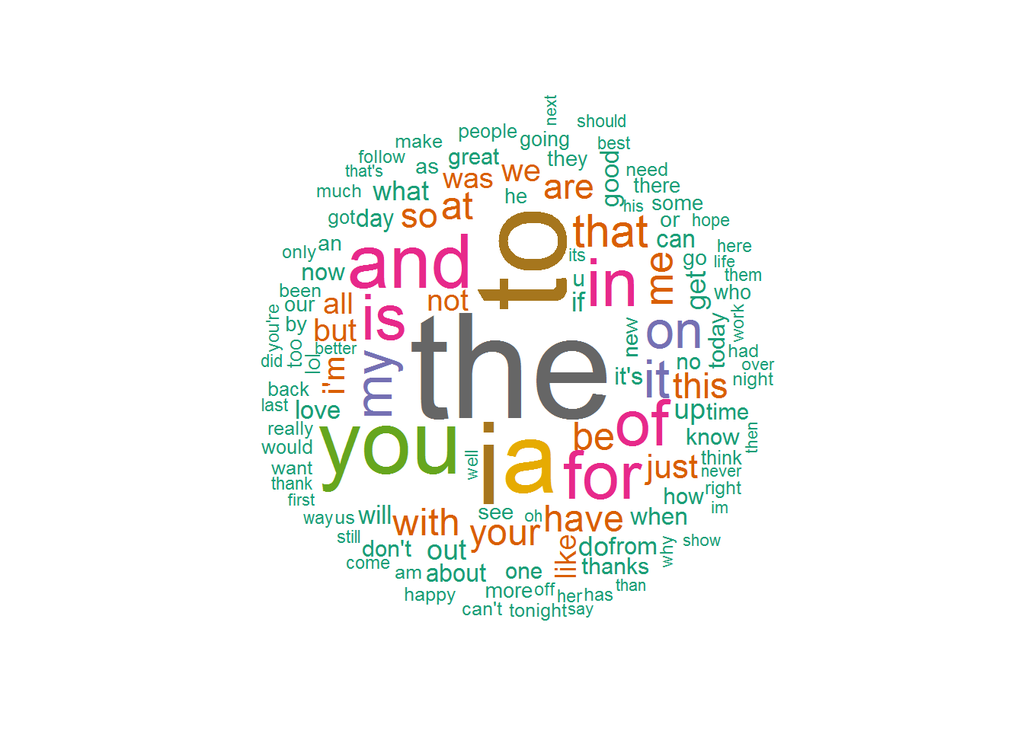

```r
visualizeWordcloud(ftm.df = frequentTermsLimited.df[-c(1,2),])
```

```r
a <- getSomeInfoABoutCorpora(allFtm.df = twitter.allTerms.1g, filter = c(1:2))
```

**How many unique words do you need in a frequency sorted dictionary to cover 50% of all word instances in the language? 90%?**

| N = number of tokens | V = vocabulary size | 50% coverage | 90% coverage |
| --- | --- | --- | --- |
| 1426356 | 59693 | 119 | 4973 |

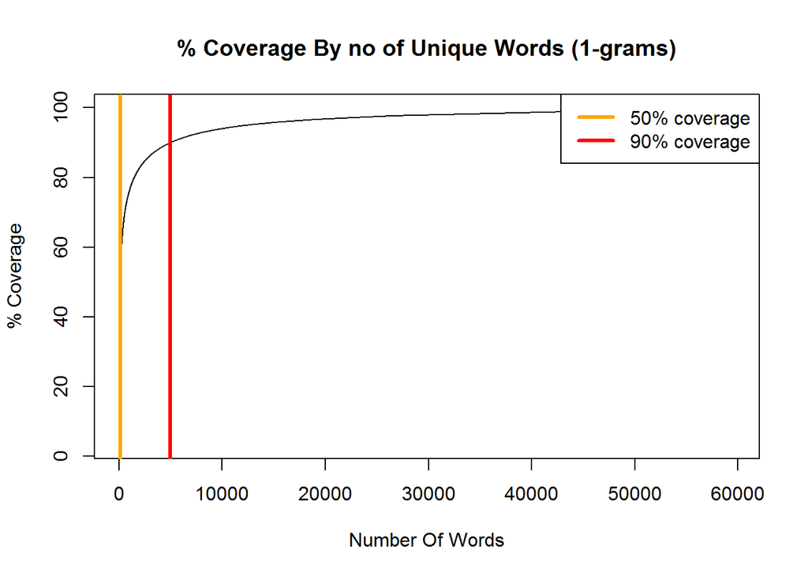

```r
visualizeCumuluativeCoverage(allFtm.df = twitter.allTerms.1g, title = "% Coverage By no of Unique Words (1-grams)", filter = c(1:2))
```

### 2-grams

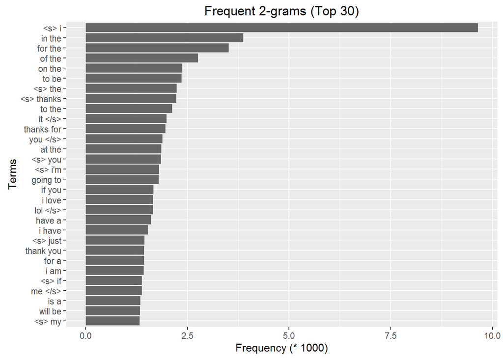

```r
corpora.tdm <- twitter.corpora.tdm.2g

ft.lf.1000 <- findFreqTerms(corpora.tdm,lowfreq = 1000)

frequentTermsLimited.df <- getTermFrequencyInformationOrderedByTermFrequency(corpora.tdm, 1000)

visualizeBarPlot(ftm.df = frequentTermsLimited.df,titleBarPlot = "Frequent 2-grams")
```

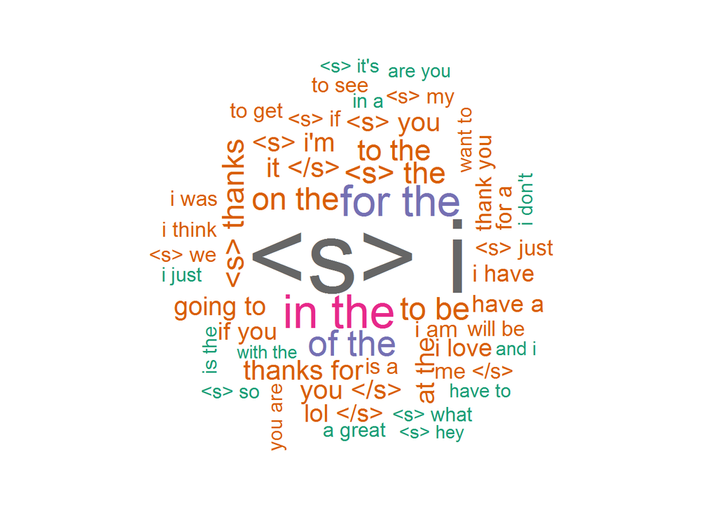

```r
visualizeWordcloud(ftm.df = frequentTermsLimited.df)
```

```r
a <- getSomeInfoABoutCorpora(allFtm.df = twitter.allTerms.2g)
```

**How many unique words do you need in a frequency sorted dictionary to cover 50% of all word instances in the language? 90%?**

| N = number of tokens | V = vocabulary size | 50% coverage | 90% coverage |
| --- | --- | --- | --- |
| 1533466 | 544417 | 16698 | 391071 |

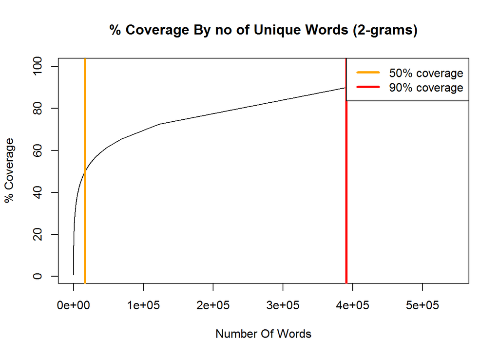

### 3-grams

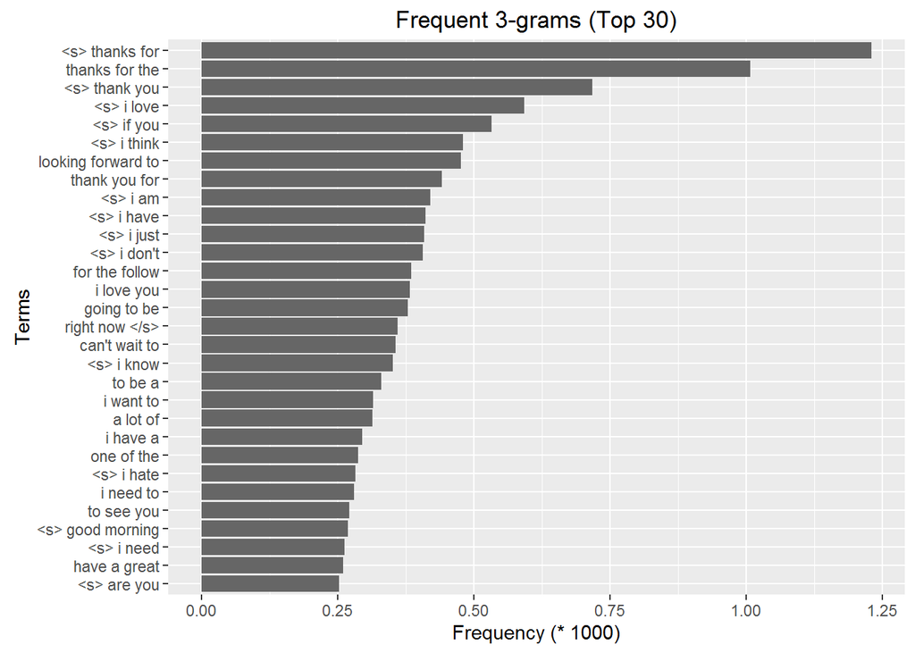

```r
corpora.tdm <- twitter.corpora.tdm.3g

ft.lf.150 <- findFreqTerms(corpora.tdm,lowfreq = 150)

frequentTermsLimited.df <- getTermFrequencyInformationOrderedByTermFrequency(corpora.tdm, 150)

visualizeBarPlot(ftm.df = frequentTermsLimited.df,titleBarPlot = "Frequent 3-grams")
```

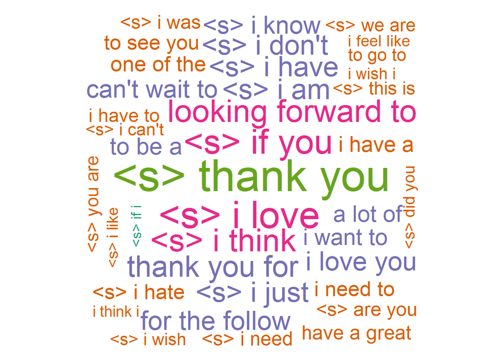

```r
visualizeWordcloud(ftm.df = frequentTermsLimited.df)
```

```r
a <- getSomeInfoABoutCorpora(allFtm.df = twitter.allTerms.3g)
```

**How many unique words do you need in a frequency sorted dictionary to cover 50% of all word instances in the language? 90%?**

| N = number of tokens | V = vocabulary size | 50% coverage | 90% coverage |
| --- | --- | --- | --- |
| 1426356 | 1060937 | 347759 | 918302 |

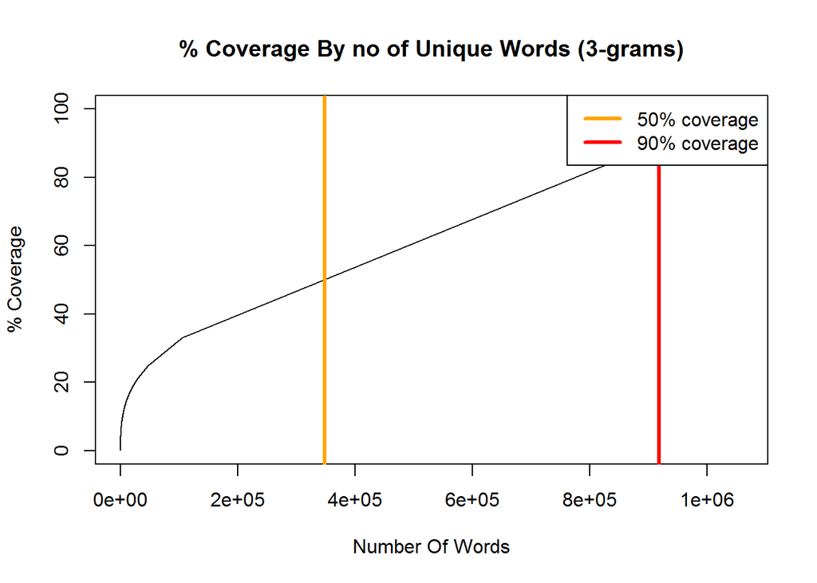

```r
visualizeCumuluativeCoverage(allFtm.df = twitter.allTerms.3g, title = "% Coverage By no of Unique Words (3-grams)")
```

## Explore Issues

```r
rm(list = ls())
load(file = "./tmp/twitter_step2_sample.1.Rdata")
load(file = "./tmp/twitter.sample1.allTermsFrequency.1g.Rdata")

twitters.contains.in <- grepl("[[:space:]]in[[:space:]]", data.twitter.sample, ignore.case = F)
idx.in <- which(twitters.contains.in)
data.twitter.sample[idx.in]

twitters.contains.in_the <- grepl("[[:space:]]in the[[:space:]]", data.twitter.sample, ignore.case = F)
idx.in_the <- which(twitters.contains.in_the)
data.twitter.sample[idx.in_the]



# ##In order to keep contractions like I'm or I'll ....
# removePunctuations.exceptApostrophe <- function(texts){
#     gsub(pattern = "[^'[:^punct:]]", replacement = " ", x = texts, perl = T)
# }
#
# test <- "I like %$@to*&, chew;: gum, but don't like|}{[] bubble@#^)( gum!? in the"
# test.expected <- "I like    to    chew   gum  but don't like      bubble      gum   in the"
# result <- removePunctuations.exceptApostrophe(texts = test)
# test.expected == result
# result
#
# ##Add start sentence (<s>) and end sentence (</s>) markers in the sentences
# addStartEndMarkers <- function(texts){
#     paste("<s>", texts, "</s>")
# }
#
# ## Removal of Profanity Words
# con <- file("./../data/original/bad-words.txt", "r")
# stopwords.profanityWords <- readLines(con, skipNul = T)
# close(con)
#
# corpora.transform <- function(x){
#   corpus <- Corpus(VectorSource(x))
#   corpus <- tm_map(corpus, content_transformer(tolower))
#   # corpus <- tm_map(corpus, removeWords, stopwords.profanityWords)
#   corpus <- tm_map(corpus, removeNumbers)
#   corpus <- tm_map(corpus, content_transformer(removePunctuations.exceptApostrophe))
#   corpus <- tm_map(corpus, content_transformer(addStartEndMarkers))
#   corpus <- tm_map(corpus, stripWhitespace)
#   corpus
# }
#
# tdm.generate.ng <- function(corpus){
#   TermDocumentMatrix(corpus) # create tdm from n-grams
# }
#
require(tm)
y <- TermDocumentMatrix(Corpus(VectorSource("i am in the process of giving up")))
y
as.matrix(y)

require(tm)
y <- TermDocumentMatrix(Corpus(VectorSource("i am in the process of giving up")), control = list(wordLengths = c(1, Inf)))
y
as.matrix(y)

#          Docs
# Terms     1
#   giving  1
#   process 1
#   the     1


corpora.transformed <- corpora.transform("i am in the process of giving up")
lapply(corpora.transformed, as.character)

corpora.tdm.1g <- tdm.generate.ng(corpora.transformed)
corpora.tdm.1g
data.frame(as.matrix(corpora.tdm.1g))
findFreqTerms(corpora.tdm.1g,100)

x <- findFreqTerms(corpora.tdm.1g,0)
sum(x == "in")
```